# A Bayesian module in an intermediate / advanced statistics course

Monika Hu

USCOTS 2021 Workshop Introducing Bayesian Statistical Analysis into Your Teaching

```r
library(tidyverse)
```

# 1 Example 1: Regressions - Bayesian vs classical

## 1.1 The data: The Consumer Expenditure Surveys (CE)

The CE sample comes from the 2019 Q1 CE PUMD: 5 variables, 5133 consumer units (CU).

Variable & Description:

- **UrbanRural**: Binary; the urban / rural status of CU: 1 = Urban, 2 = Rural.
- **Income**: Continuous; the amount of CU income before taxes in past 12 months (in $USD$).
- **Race**: Categorical; the race category of the reference person: 1 = White, 2 = Black, 3 = Native American, 4 = Asian, 5 = Pacific Islander, 6 = Multi-race.
- **Expenditure**: Continuous; CU’s total expenditures in last quarter (in $USD$).
- **KidsCount**: Count; the number of CU members under age 16. |

```r
CEdata <- readr::read_csv(file = "CEdata.csv")
CEdata[1:3, ]
```

```
## # A tibble: 3 x 5
##   UrbanRural Income  Race Expenditure KidsCount
##        <dbl>  <dbl> <dbl>       <dbl>     <dbl>
## 1          1  73720     1      27542.         3
## 2          1  12000     1       7416.         2
## 3          1  20000     1       8608.         0
```

## 1.2 Simple linear regression

- **LogIncome**: predictor variable
- **LogExpenditure**: outcome variable

```r
CEdata$LogIncome <- log(CEdata$Income)
CEdata$LogExpenditure <- log(CEdata$Expenditure)
```

### 1.2.1 Highlights in teaching

- This is a multi-parameter model
- The Bayesian inference framework:
  - parameters are random variables with distributions that quantify degree of uncertainty
  - posterior is proportional to likelihood times prior
- Markov chain Monte Carlo (MCMC) estimation:
  - why
  - how
- MCMC diagnostics
  - why
  - how
- Inference
  - credible intervals vs confidence intervals, hypothesis testing
  - prediction
  - model checking
  - evaluating prior choices
  - comparison to classical inference

### 1.2.2 Bayesian inference with the brms package

```r
# make sure to install and load the library
library(brms)
```

#### 1.2.2.1 The model and Bayesian inference framework

$$\begin{eqnarray}
Y_i \mid \mu_i, \sigma &\overset{ind}{\sim}& \textrm{Normal}(\mu_i, \sigma), \\
\mu_i &=& \beta_0 + \beta_1 x_i.
\end{eqnarray}$$

- Model parameters: $\{\beta_0, \beta_1, \sigma\}$
- Bayesian inference:
  - Prior for $\{\beta_0, \beta_1, \sigma\}$
  - Sampling model for $Y_1, \cdots, Y_n \mid \mu_i, \sigma$
  - Posterior for $\{\beta_0, \beta_1, \sigma\}$

#### 1.2.2.2 Choosing a prior

Check the default prior provided by the `brms` package.

```r
brms::get_prior(data = CEdata,
                family = gaussian,
                formula = LogExpenditure ~ 1 + LogIncome)
```

```
##                   prior     class      coef group resp dpar nlpar bound
##                  (flat)         b
##                  (flat)         b LogIncome
##  student_t(3, 8.9, 2.5) Intercept
##    student_t(3, 0, 2.5)     sigma
##        source
##       default
##  (vectorized)
##       default
##       default
```

One can also use one’s own priors, e.g., using the following in the `brm()` function.

```r
prior = c(prior(normal(0, 10), class = Intercept),
          prior(normal(0, 10), class = b),
          prior(cauchy(0, 1), class = sigma))
```

#### 1.2.2.3 MCMC estimation

```r
SLR_Bayes_fit <- brms::brm(data = CEdata,
                           family = gaussian,
                           formula = LogExpenditure ~ 1 + LogIncome,
                           iter = 5000,
                           warmup = 3000,
                           thin = 1,
                           chains = 1,
                           seed = 720)
```

#### 1.2.2.4 MCMC diagnostics

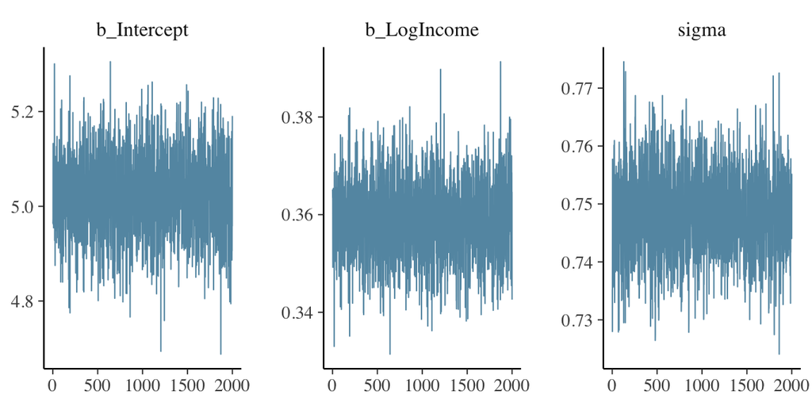

```r
library(bayesplot)
bayesplot::mcmc_trace(x = SLR_Bayes_fit,
                      pars = c("b_Intercept", "b_LogIncome", "sigma"))
```

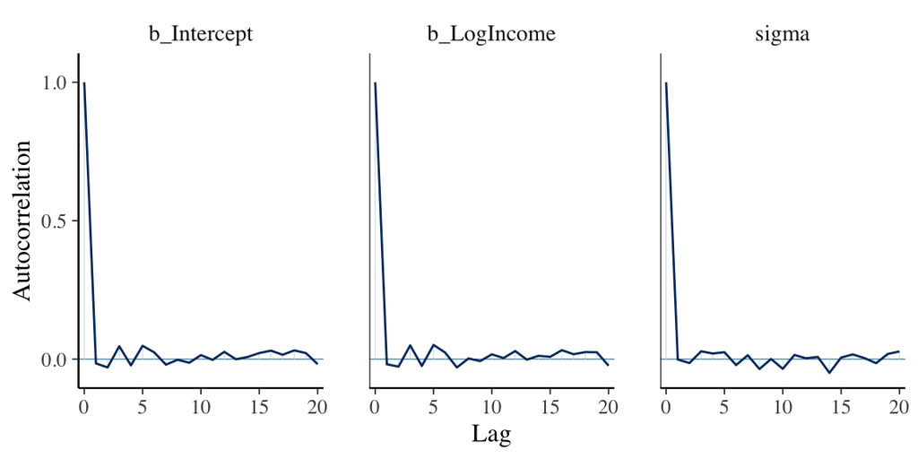

```r
bayesplot::mcmc_acf(x = SLR_Bayes_fit,
                    pars = c("b_Intercept", "b_LogIncome", "sigma"))
```

#### 1.2.2.5 Posterior inference

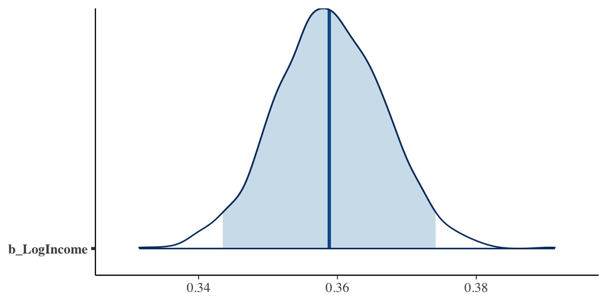

```r
post_SLR <- brms::posterior_samples(x = SLR_Bayes_fit)
bayesplot::mcmc_areas(post_SLR, pars = "b_LogIncome", prob = 0.95)
```

```r
quantile(post_SLR$b_LogIncome, c(0.025, 0.975))
```

```
##      2.5%     97.5%
## 0.3434765 0.3741420
```

A 95% **credible interval** for the slope of LogIncome is [0.34, 0.37].

```r
summary(SLR_Bayes_fit)
```

```
##  Family: gaussian
##   Links: mu = identity; sigma = identity
## Formula: LogExpenditure ~ 1 + LogIncome
##    Data: CEdata (Number of observations: 5133)
## Samples: 1 chains, each with iter = 5000; warmup = 3000; thin = 1;
##          total post-warmup samples = 2000
##
## Population-Level Effects:
##           Estimate Est.Error l-95% CI u-95% CI Rhat Bulk_ESS Tail_ESS
## Intercept     5.02      0.08     4.85     5.19 1.00     1922     1525
## LogIncome     0.36      0.01     0.34     0.37 1.00     1864     1455
##
## Family Specific Parameters:
##       Estimate Est.Error l-95% CI u-95% CI Rhat Bulk_ESS Tail_ESS
## sigma     0.75      0.01     0.73     0.76 1.00     1891     1404
##
## Samples were drawn using sampling(NUTS). For each parameter, Bulk_ESS
## and Tail_ESS are effective sample size measures, and Rhat is the potential
## scale reduction factor on split chains (at convergence, Rhat = 1).
```

Additional inference:

- **Prediction**: `predict(fit)`
- **Model checking (posterior predictive check)**: `pp_check(fit)`
- Evaluation of prior choices

### 1.2.3 Classical inference with the lm package

```r
SLR_classical_fit <- lm(formula = LogExpenditure ~ 1 + LogIncome,
                        data = CEdata)

summary(SLR_classical_fit)
```

```
##
## Call:
## lm(formula = LogExpenditure ~ 1 + LogIncome, data = CEdata)
##
## Residuals:
##     Min      1Q  Median      3Q     Max
## -2.9138 -0.5161  0.0202  0.4822  4.5287
##
## Coefficients:
##             Estimate Std. Error t value Pr(>|t|)
## (Intercept) 5.025288   0.086695   57.97   <2e-16 ***
## LogIncome   0.358586   0.008073   44.42   <2e-16 ***
## ---
## Signif. codes:  0 '***' 0.001 '**' 0.01 '*' 0.05 '.' 0.1 ' ' 1
##
## Residual standard error: 0.7483 on 5131 degrees of freedom
## Multiple R-squared:  0.2777, Adjusted R-squared:  0.2776
## F-statistic:  1973 on 1 and 5131 DF,  p-value: < 2.2e-16
```

```r
confint.default(SLR_classical_fit)
```

```
##                 2.5 %    97.5 %
## (Intercept) 4.8553683 5.1952069
## LogIncome   0.3427627 0.3744087
```

A 95% **confidence interval** of the slope of LogIncome is [0.34, 0.37].

#### 1.2.3.1 Sample script for multiple linear regression

- Own prior choice

```r
MLR_Bayes_fit_1 <- brm(data = CEdata,
                       family = gaussian,
                       formula = LogExpenditure ~ 1 + LogIncome + as.factor(UrbanRural),
                       prior = c(prior(normal(0, 10), class = Intercept),
                                 prior(normal(0, 10), class = b),
                                 prior(cauchy(0, 1), class = sigma)),
                       iter = 5000,
                       warmup = 3000,
                       thin = 1,
                       chains = 1,
                       seed = 129)
```

- Default prior choice

```r
MLR_Bayes_fit_2 <- brm(data = CEdata,
                       family = gaussian,
                       formula = LogExpenditure ~ 1 + LogIncome + as.factor(UrbanRural),
                       iter = 5000,
                       warmup = 3000,
                       thin = 1,
                       chains = 1,
                       seed = 129)
```

## 1.3 Logistic regression

- **LogExpenditure**: predictor variable
- **UrbanRural**: outcome variable (minus 1)

### 1.3.1 Bayesian inference with the brms package

#### 1.3.1.1 Choosing a prior

Check the default prior provided by the `brms` package.

```r
brms::get_prior(data = CEdata,
                family = binomial(link = "logit"),
                formula = (UrbanRural - 1) ~ 1 + LogExpenditure)
```

```
##                 prior     class           coef group resp dpar nlpar bound
##                (flat)         b
##                (flat)         b LogExpenditure
##  student_t(3, 0, 2.5) Intercept
##        source
##       default
##  (vectorized)
##       default
```

One can also use one’s own priors.

#### 1.3.1.2 MCMC estimation

```r
logistic_Bayes_fit <- brms::brm(data = CEdata,
                                family = binomial(link = "logit"),
                                formula = (UrbanRural - 1) ~ 1 + LogExpenditure,
                                iter = 5000,
                                warmup = 3000,
                                thin = 1,
                                chains = 1,
                                seed = 257)
```

#### 1.3.1.3 MCMC diagnostics

Sample script:

```r
bayesplot::mcmc_trace(x = logistic_Bayes_fit,
                      pars = c("b_Intercept", "b_LogExpenditure"))
bayesplot::mcmc_acf(x = logistic_Bayes_fit,
                    pars = c("b_Intercept", "b_LogExpenditure"))
```

#### 1.3.1.4 Posterior inference

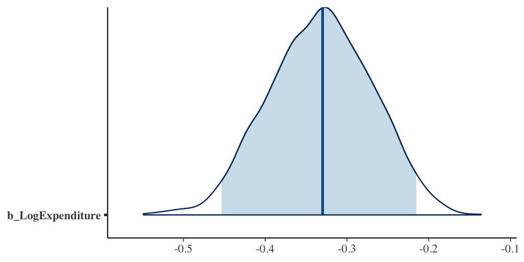

```r
post_logistic <- brms::posterior_samples(x = logistic_Bayes_fit)
bayesplot::mcmc_areas(post_logistic, pars = "b_LogExpenditure", prob = 0.95)
```

```r
quantile(post_logistic$b_LogExpenditure, c(0.025, 0.975))
```

```
##       2.5%      97.5%
## -0.4535233 -0.2151616
```

A 95% **credible interval** for the slope of LogExpenditure is [-0.45, -0.22].

```r
summary(logistic_Bayes_fit)
```

```
##  Family: binomial
##   Links: mu = logit
## Formula: (UrbanRural - 1) ~ 1 + LogExpenditure
##    Data: CEdata (Number of observations: 5133)
## Samples: 1 chains, each with iter = 5000; warmup = 3000; thin = 1;
##          total post-warmup samples = 2000
##
## Population-Level Effects:
##                Estimate Est.Error l-95% CI u-95% CI Rhat Bulk_ESS Tail_ESS
## Intercept          0.24      0.54    -0.79     1.29 1.00     1293     1149
## LogExpenditure    -0.33      0.06    -0.45    -0.22 1.00     1247     1307
##
## Samples were drawn using sampling(NUTS). For each parameter, Bulk_ESS
## and Tail_ESS are effective sample size measures, and Rhat is the potential
## scale reduction factor on split chains (at convergence, Rhat = 1).
```

Additional inference:

- **Prediction**: `predict(fit)`
- **Model checking (posterior predictive check)**: `pp_check(fit)`
- Evaluation of prior choices

### 1.3.2 Classical inference with the glm package

```r
logistic_classical_fit <- glm(formula =  (UrbanRural - 1) ~ 1 + LogExpenditure,
                              family = binomial(link = "logit"),
                              data = CEdata)

summary(logistic_classical_fit)
```

```
##
## Call:
## glm(formula = (UrbanRural - 1) ~ 1 + LogExpenditure, family = binomial(link = "logit"),
##     data = CEdata)
##
## Deviance Residuals:
##     Min       1Q   Median       3Q      Max
## -0.6595  -0.3937  -0.3554  -0.3212   2.8525
##
## Coefficients:
##                Estimate Std. Error z value Pr(>|z|)
## (Intercept)     0.23124    0.54950   0.421    0.674
## LogExpenditure -0.33042    0.06337  -5.214 1.85e-07 ***
## ---
## Signif. codes:  0 '***' 0.001 '**' 0.01 '*' 0.05 '.' 0.1 ' ' 1
##
## (Dispersion parameter for binomial family taken to be 1)
##
##     Null deviance: 2486.9  on 5132  degrees of freedom
## Residual deviance: 2459.9  on 5131  degrees of freedom
## AIC: 2463.9
##
## Number of Fisher Scoring iterations: 5
```

```r
confint.default(logistic_classical_fit)
```

```
##                     2.5 %     97.5 %
## (Intercept)    -0.8457646  1.3082349
## LogExpenditure -0.4546259 -0.2062149
```

A 95% **confidence interval** of the slope of LogExpenditure is [-0.45, -0.21].

## 1.4 Multinomial logistic regression

- **LogIncome**: predictor variable
- **Race**: outcome variable

### 1.4.1 Bayesian inference sample script with default priors

```r
multi_logistic_Bayes_fit <- brms::brm(data = CEdata,
                                      family = categorical(link = "logit"),
                                      Race ~ 1 + LogIncome,
                                      iter = 5000,
                                      warmup = 3000,
                                      thin = 1,
                                      chains = 1,
                                      seed = 843)
```

### 1.4.2 Classical inference with the nnet package

```r
library(nnet)
multi_logistic_classical_fit <- nnet::multinom(formula =  Race ~ 1 + LogIncome,
                                               data = CEdata)
```

## 1.5 Poisson regression

- **LogIncome** & **LogExpenditure**: predictor variables
- **KidsCount**: outcome variable

### 1.5.1 Bayesian inference sample script with default priors

```r
Poisson_Bayes_fit <- brms::brm(data = CEdata,
                               family = poisson(link = "log"),
                               formula = KidsCount ~ 1 + LogIncome + LogExpenditure,
                               iter = 5000,
                               warmup = 3000,
                               thin = 1,
                               chains = 1,
                               seed = 853)
```

### 1.5.2 Classical inference with the glm package

```r
Poisson_classical_fit <- glm(formula =  KidsCount ~ 1 + LogIncome + LogExpenditure,
                             family = poisson(link = "log"),
                             data = CEdata)
```

# 2 Example 2: Hierarchical models

## 2.1 The data: The animation movie ratings from 2010

Sample from MovieLens; 8 animation movies with 55 ratings. Each rating is for a movie completed by a user; some movies have many ratings while others have few (fewest: only 1 rating).

- **Title**: movie title
- **Rating**: movie rating by a user

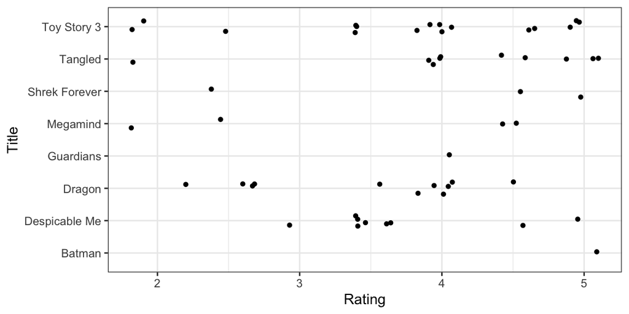

## 2.2 Highlights in teaching

- Bayesian approaches are natural for observations nested in groups
- Using 2 or more MCMC chains
  - diagnostics
  - inference
- Inference
  - credible intervals vs confidence intervals, hypothesis testing
  - prediction
  - model checking
  - evaluating prior choices
- Additional inference
  - shrinkage / pooling effects
  - sources of variability

## 2.3 A hierarchical / multi-level model

### 2.3.1 The sampling model

- Without loss of generality, assume a group-specific normal model for movie $j$:
  $$\begin{eqnarray}
  Y_{ij} \overset{i.i.d.}{\sim} \textrm{Normal}(\mu_j, \sigma),
  \end{eqnarray}$$
  where $i = 1, \cdots, n_j$ and $n_j$ is the number of observations in group $j$.
- Is a commonly shared $\sigma$ reasonable? If not, $\sigma$ can be group-specific.
- Model parameters: $\{\mu_1, \cdots, \mu_J, \sigma\}$.

### 2.3.2 A two-stage prior for $\{\mu_1, \cdots, \mu_J\}$

**Stage 1**

- All movies are animation movies, we could assume that the mean ratings are similar across movies
- First stage: the same normal prior distribution for each mean $\mu_j$
  $$\begin{equation}
  \mu_j \mid \mu, \tau \sim \textrm{Normal}(\mu, \tau).
  \end{equation}$$
- This prior allows information pooled across movies (groups).
  - If $\tau$ is large, the $\mu_j$’s are very different a priori $\rightarrow$ modest pooling in parameter estimation.
  - If $\tau$ is small, the $\mu_j$’s are very similar a priori $\rightarrow$ large pooling in parameter estimation.
- $\mu$ and $\tau$: hyperparameters, and treated random.

**Stage 2**

- Second stage: weakly informative hyperpriors for hyperparameters
  $$\begin{eqnarray}
  \mu &\sim& \textrm{Normal}(3, 1), \\
  \tau &\sim& \textrm{Cauchy}^+(0, 1).
  \end{eqnarray}$$
- After posterior inference:
  - The posterior of $\mu$ is informative about an average mean rating.
  - The posterior of $\tau$ is informative about the variation among the $\mu_j$’s.

**Others**

- Weakly informative prior for $\sigma$:
  $$\begin{eqnarray}
  \sigma &\sim& \textrm{Cauchy}^+(0, 1).
  \end{eqnarray}$$

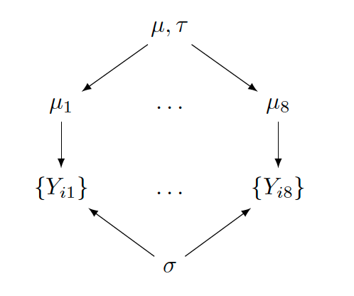

## 2.4 Bayesian inference with the brms package

### 2.4.1 MCMC estimation

Use chosen priors; one can also use default priors.

```r
library(brms)
hm_fit <- brms::brm(data = MovieRatings,
                    family = gaussian,
                    formula = rating ~ 1 + (1 | Title),
                    prior = c(prior(normal(3, 1), class = Intercept),
                              prior(cauchy(0, 1), class = sd),
                              prior(cauchy(0, 1), class = sigma)),
                    iter = 20000,
                    warmup = 10000,
                    thin = 10,
                    chains = 2,
                    seed = 852)
```

### 2.4.2 MCMC diagnostics

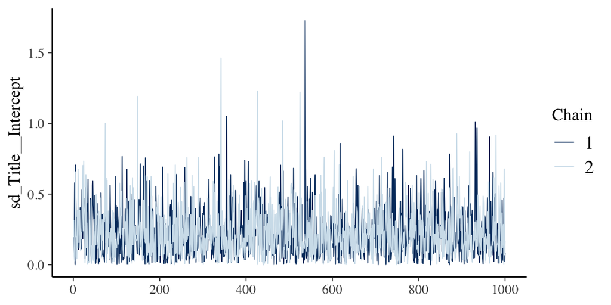

```r
library(bayesplot)
bayesplot::mcmc_trace(x = hm_fit,
                      pars = c("sd_Title__Intercept"))
```

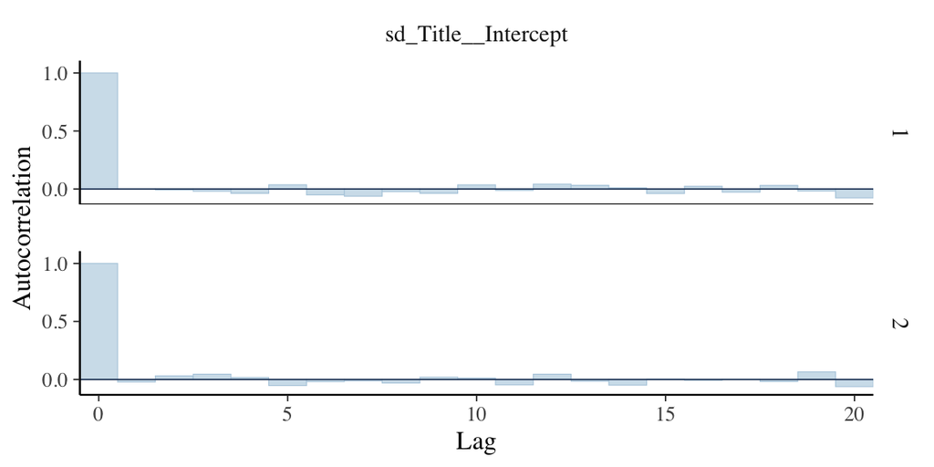

```r
bayesplot::mcmc_acf_bar(x = hm_fit,
                        pars = c("sd_Title__Intercept"))
```

### 2.4.3 Posterior inference

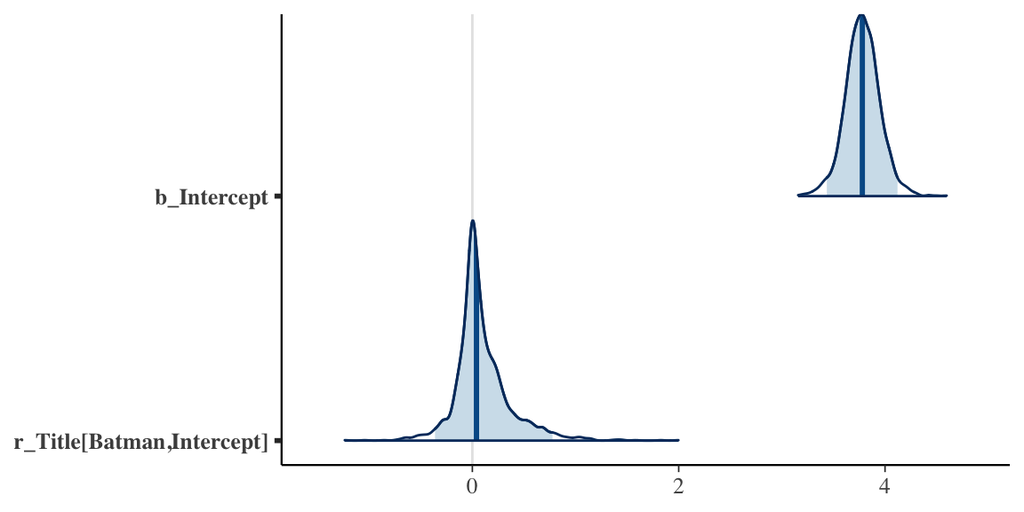

```r
post_hm <- posterior_samples(hm_fit)
bayesplot::mcmc_areas(x = post_hm,
                      pars = c("b_Intercept", "r_Title[Batman,Intercept]"),
                      prob = 0.95)
```

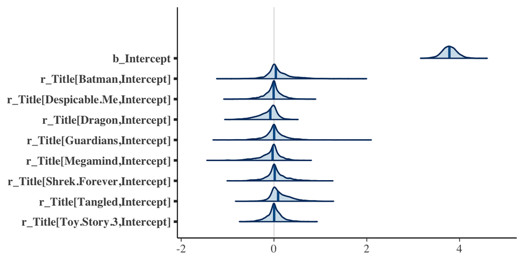

```r
bayesplot::mcmc_areas(x = post_hm,
                      pars = c("b_Intercept",
                               "r_Title[Batman,Intercept]",
                               "r_Title[Despicable.Me,Intercept]",
                               "r_Title[Dragon,Intercept]",
                               "r_Title[Guardians,Intercept]",
                               "r_Title[Megamind,Intercept]",
                               "r_Title[Shrek.Forever,Intercept]",
                               "r_Title[Tangled,Intercept]",
                               "r_Title[Toy.Story.3,Intercept]"),
                      prob = 0.95)
```

Additional inference:

- **Prediction**: `predict(fit)`
- **Model checking (posterior predictive check)**: `pp_check(fit)`
- **Shrinkage / pooling effects**:

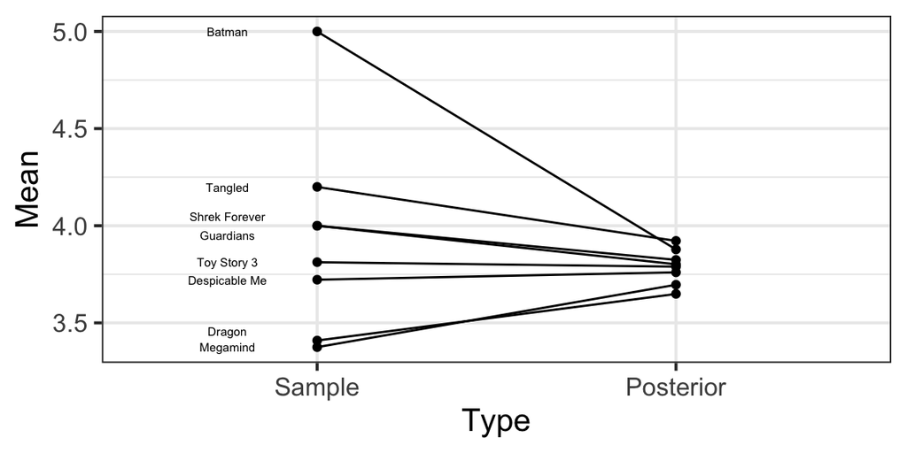

- **Sources of variability**:
- Two sources of variability in $Y_{ij}$:
  $$\begin{eqnarray*}
  Y_{ij} &\overset{i.i.d.}{\sim}& \textrm{Normal}(\mu, \sigma) \,\,\, \text{[within-group variability]} \\
  \mu_j &\sim& \textrm{Normal}(\mu, \tau) \,\,\, \text{[between-group variability]}
  \end{eqnarray*}$$
- To compare these two sources of variability, one can compute the fraction
  $$\begin{equation*}
  R = \frac{\tau^2}{\tau^2 + \sigma^2}
  \end{equation*}$$
  from the posterior draws of $\tau$ and $\sigma$.
- If $R \rightarrow 1$, the higher the between-group variability.

```
##         2.5%        97.5%
## 0.0001469417 0.3598463504
```

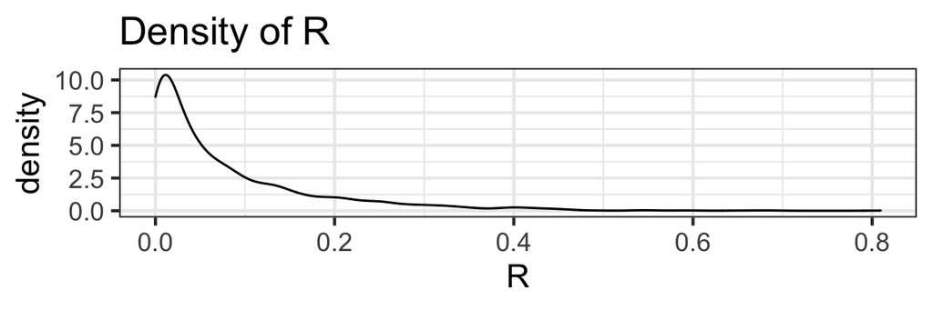

```r
tau_draws <- post_hm[,"sd_Title__Intercept"]
sigma_draws <- post_hm[,"sigma"]
R <- tau_draws^2/(tau_draws^2 + sigma_draws^2)
quantile(R, c(0.025, 0.975))
```

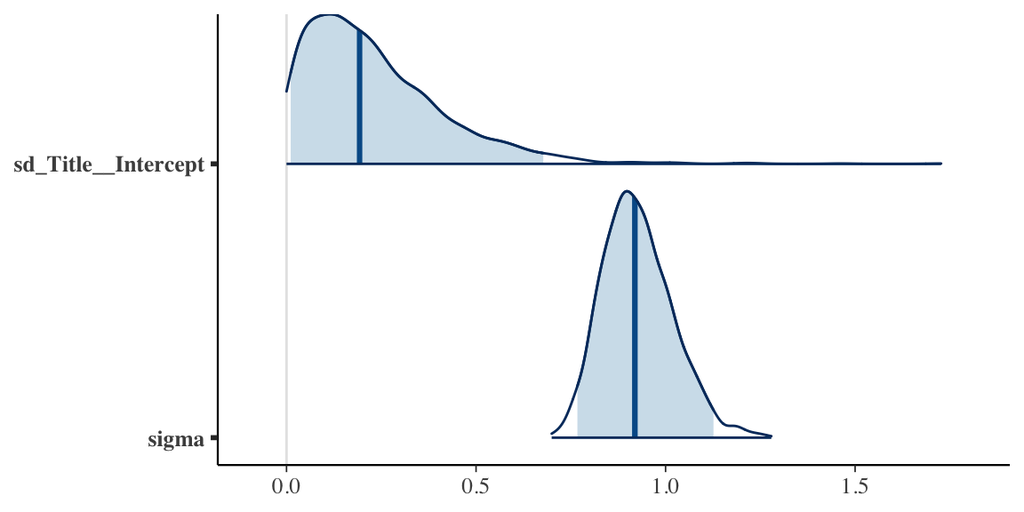

```r
bayesplot::mcmc_areas(x = post_hm,
                      pars = c("sd_Title__Intercept", "sigma"),
                      prob = 0.95)
```